# Practice_Midterm

2025-03-03

```r
install.packages("fpp2", repos = "https://cloud.r-project.org/")
library(fpp2)
library(ggplot2)
```

```r
data("arrivals")  # Load the dataset
head(arrivals)    # View the first few rows
```

```
##          Japan     NZ     UK     US
## 1981 Q1 14.763 49.140 45.266 32.316
## 1981 Q2  9.321 87.467 19.886 23.721
## 1981 Q3 10.166 85.841 24.839 24.533
## 1981 Q4 19.509 61.882 52.264 33.438
## 1982 Q1 17.117 42.045 53.636 33.527
## 1982 Q2 10.617 63.081 34.802 28.366
```

```r
summary(arrivals)
```

```
##      Japan               NZ               UK               US
##  Min.   :  9.321   Min.   : 37.04   Min.   : 19.89   Min.   : 23.72
##  1st Qu.: 74.135   1st Qu.: 96.52   1st Qu.: 53.89   1st Qu.: 63.95
##  Median :135.461   Median :154.54   Median : 95.56   Median : 85.88
##  Mean   :122.080   Mean   :170.59   Mean   :106.86   Mean   : 84.85
##  3rd Qu.:176.752   3rd Qu.:228.60   3rd Qu.:128.13   3rd Qu.:108.98
##  Max.   :227.641   Max.   :330.81   Max.   :269.29   Max.   :136.09
```

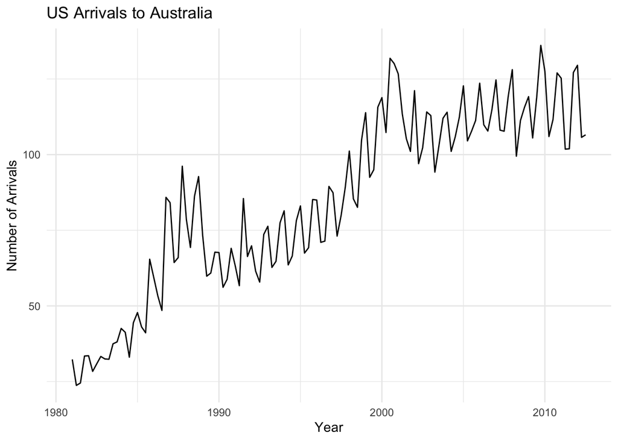

```r
us_arrivals <- arrivals[, "US"]

# Plot the time series
autoplot(us_arrivals) +
  ggtitle("US Arrivals to Australia") +
  xlab("Year") +
  ylab("Number of Arrivals") +
  theme_minimal()
```

### This time series shows that there is a gradual increase of travel from the U.S. to Austrailia from around 1980 to 2000, which then remained somewhat stagnant from 2000-2010s.

```r
summary(us_arrivals)
```

```
##    Min. 1st Qu.  Median    Mean 3rd Qu.    Max.
##   23.72   63.95   85.88   84.85  108.98  136.09
```

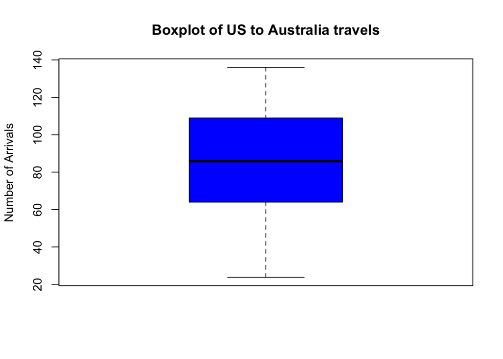

```r
boxplot(us_arrivals, main = "Boxplot of US to Australia travels", ylab = "Number of Arrivals", col = "blue")
```

## Summary Stats Observations:

#### The lowest number of recorded arrivals is 23.72 flights, the 1st quartile is 63.95 flights, meaning that 25% of the data falls below this value, the median is 85.88 flights, which means half of the data points are below this number and half are above. The mean is 84.85 which is the average number of arrivals, the 3rd quartile is 108.98 flights which means 75% of the data falls below this value and max is 136.09 flights which the highest recorded number of arrivals.

## Boxplot Stats Observations:

#### The box which IQR ranges from 63.95 - 108.98 represents the middle 50% of the data, showing a moderate spread. The whiskers extend from 23.72 (min) to 136.09 (max) covering the whole range of values. And there doesn’t seem to be an apparent outliers.

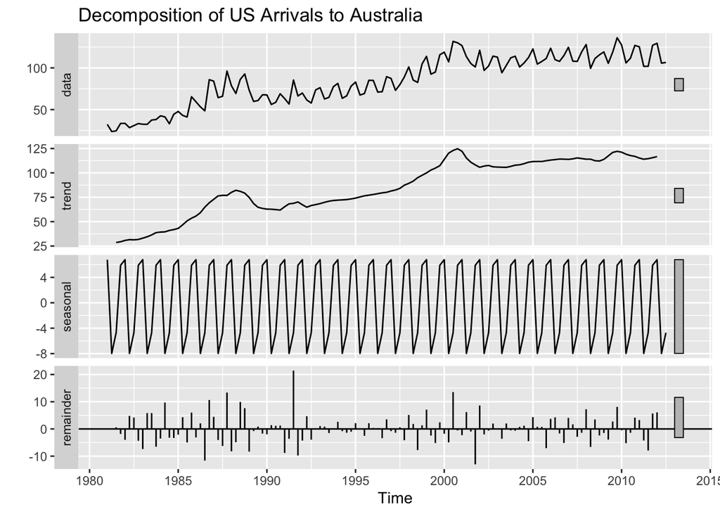

```r
us_decomp1 <- decompose(us_arrivals)
autoplot(us_decomp1) + ggtitle("Decomposition of US Arrivals to Australia")
```

#### The time series of US arrivals to Australia is seasonal. This is because we can clearly see repeating wave-like patterns and the trend component shows a general increase over time.

#### The decomposition model is additive. This is because there is a constant seasonal amplitude as it remains relatively consistent over time. There also is a smooth increasing pattern within the trend component as well.

### There appears to be seasonality! Let’s find the seasonal monthly indices:

```r
seasonal_indices <- us_decomp1$seasonal
monthly_indices <- tapply(seasonal_indices, cycle(seasonal_indices), mean)
print(monthly_indices)
```

```
##         1         2         3         4
##  6.784749 -7.969292 -4.717247  5.901790
```

#### Since the dataset is in a quarterly basis, we have a range of 3 months. The months in which the time series value is high is the first quarter of the year, and the months in which the time series value is lowest is the second quarter of the year. The reason why the first quarter may be higher is because this is the post-holiday time of the year or winter breaks. The reason why the second quarter is the lowest is because there are fewer breaks available during April and May specifically, and late June is the beginning of summer break.

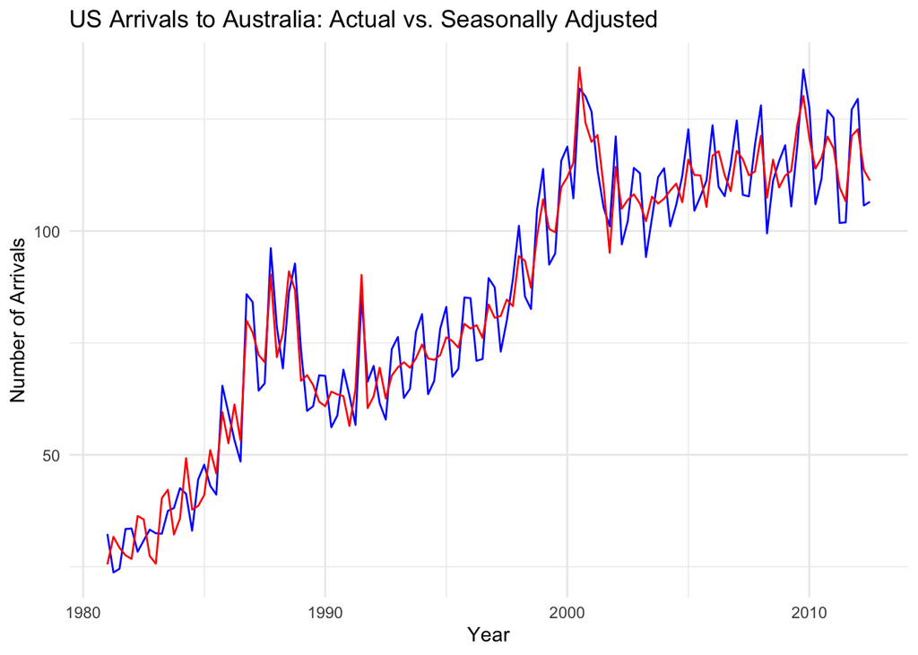

```r
seasonally_adjusted <- us_arrivals - us_decomp1$seasonal
autoplot(us_arrivals, series = "Actual Data", color = "blue") +
  autolayer(seasonally_adjusted, series = "Seasonally Adjusted", color = "red") +
  ggtitle("US Arrivals to Australia: Actual vs. Seasonally Adjusted") +
  ylab("Number of Arrivals") +
  xlab("Year") +
  scale_color_manual(values = c("Actual Data" = "blue", "Seasonally Adjusted" = "red")) +
  theme_minimal()
```

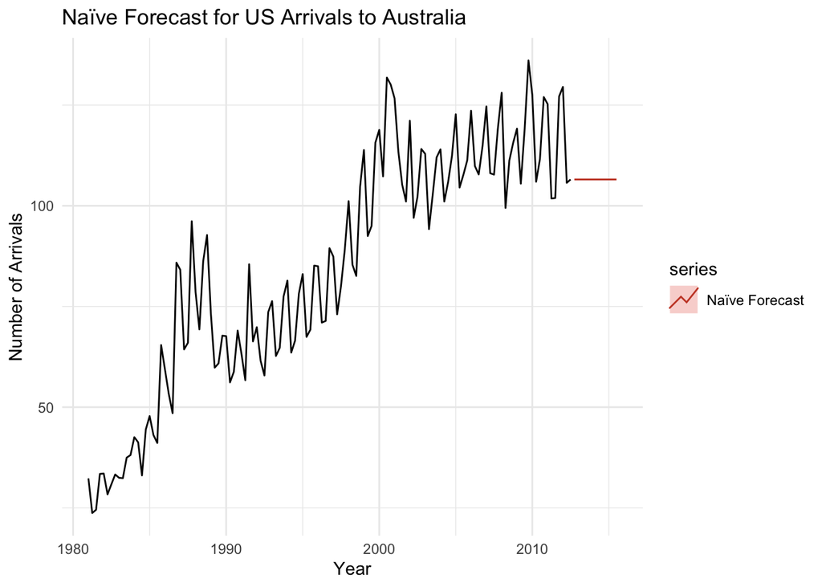

```r
naive_forecast <- naive(us_arrivals, h = 12)
autoplot(us_arrivals) +
  autolayer(naive_forecast, series = "Naïve Forecast", PI = FALSE) +
  ggtitle("Naïve Forecast for US Arrivals to Australia") +
  ylab("Number of Arrivals") +
  xlab("Year") +
  theme_minimal()
```

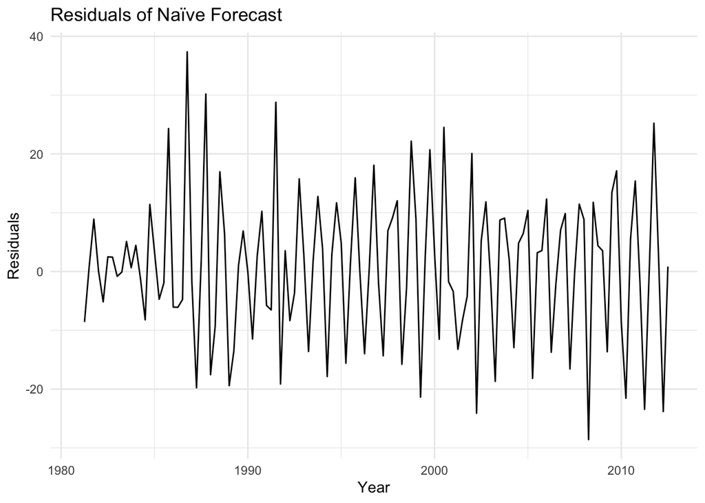

```r
naive_residuals <- residuals(naive_forecast)
autoplot(naive_residuals) +
  ggtitle("Residuals of Naïve Forecast") +
  ylab("Residuals") +
  xlab("Year") +
  theme_minimal()
```

#### This indicates that seasonality is present and that there is a pattern present here. With residuals they would be randomly scattered around 9 but there are sort of cyclical fluctations around 0.

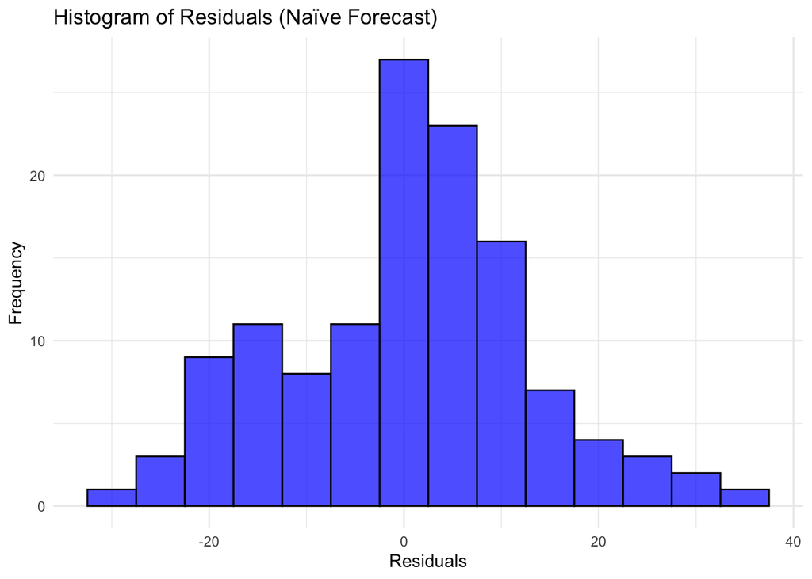

```r
ggplot(data = data.frame(naive_residuals), aes(x = naive_residuals)) +
  geom_histogram(binwidth = 5, fill = "blue", color = "black", alpha = 0.7) +
  ggtitle("Histogram of Residuals (Naïve Forecast)") +
  xlab("Residuals") +
  ylab("Frequency") +
  theme_minimal()
```

#### This histogram indicates that the residuals are somewhat normally distributed. It is slightly skewed which shows that forecast errors are not perfectly symmetric.

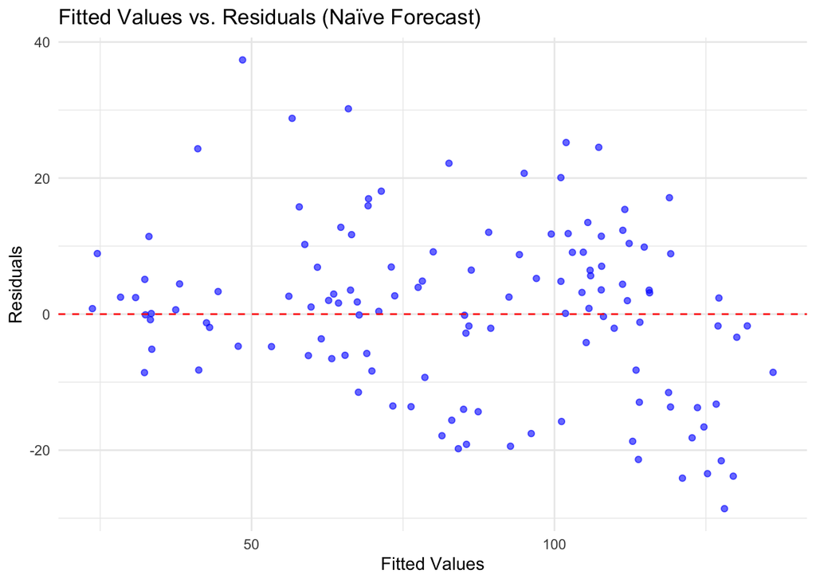

```r
residuals_df <- data.frame(
  Fitted_Values = fitted(naive_forecast),
  Residuals = naive_residuals
)

ggplot(residuals_df, aes(x = Fitted_Values, y = Residuals)) +
  geom_point(color = "blue", alpha = 0.6) +
  geom_hline(yintercept = 0, color = "red", linetype = "dashed") +
  ggtitle("Fitted Values vs. Residuals (Naïve Forecast)") +
  xlab("Fitted Values") +
  ylab("Residuals") +
  theme_minimal()
```

#### This plot shows that the residuals are not perfectly random, showing that the Naive model does not fully capture trend or seasonality. We can see that maybe the variance of errors change with the fitted values as there is an uneven spread.

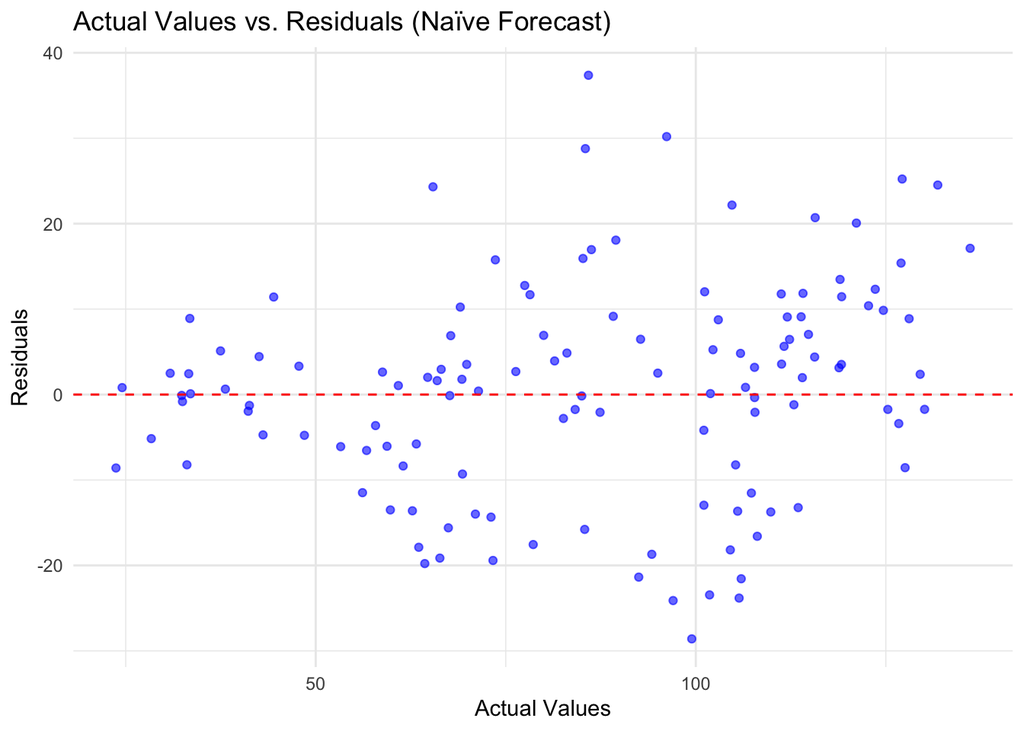

```r
residuals_df <- data.frame(
  Actual_Values = us_arrivals,
  Residuals = naive_residuals
)

ggplot(residuals_df, aes(x = Actual_Values, y = Residuals)) +
  geom_point(color = "blue", alpha = 0.6) +
  geom_hline(yintercept = 0, color = "red", linetype = "dashed") +
  ggtitle("Actual Values vs. Residuals (Naïve Forecast)") +
  xlab("Actual Values") +
  ylab("Residuals") +
  theme_minimal()
```

#### This plot shoes uneven error variance and autocorrelation which indicates that the Naive model once again does not show seasonality or trends.

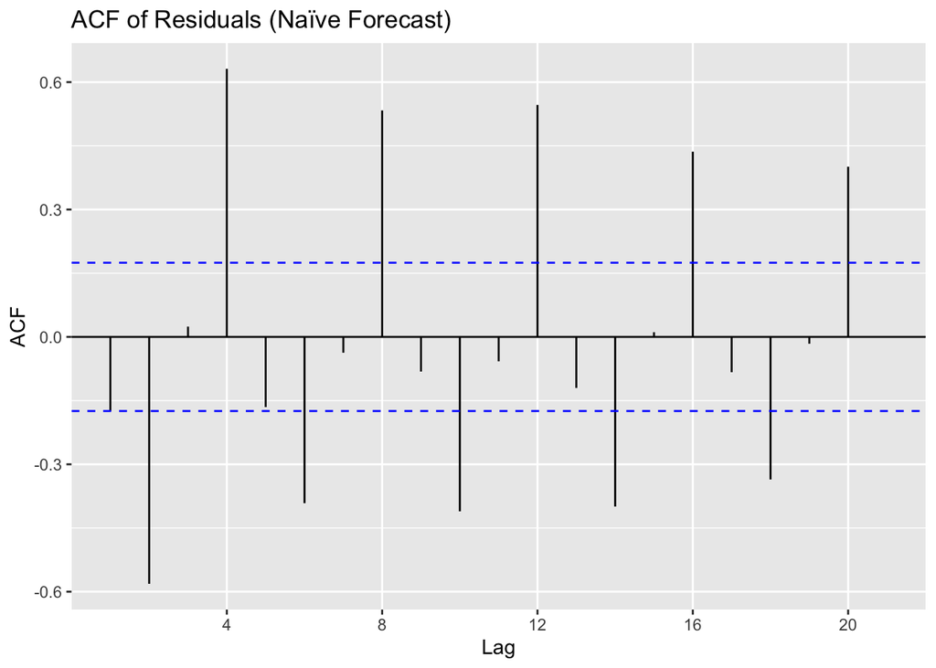

```r
ggAcf(naive_residuals) +
  ggtitle("ACF of Residuals (Naïve Forecast)")
```

#### There are significant spikes at the regular intervals and exceed the blue dashed significance lines, which means that residuals are correlated at these lags. This could suggest seasonality!

```r
accuracy_measures <- accuracy(naive_forecast)
print(accuracy_measures)
```

```
##                     ME     RMSE      MAE        MPE     MAPE     MASE
## Training set 0.5890794 12.51291 9.689444 -0.2367242 11.82787 1.312846
##                    ACF1
## Training set -0.1743858
```

```r
forecast_table <- data.frame(naive_forecast)
print(forecast_table)
```

```
##         Point.Forecast    Lo.80    Hi.80    Lo.95    Hi.95
## 2012 Q4         106.54 90.50406 122.5759 82.01515 131.0648
## 2013 Q1         106.54 83.86176 129.2182 71.85663 141.2234
## 2013 Q2         106.54 78.76494 134.3151 64.06172 149.0183
## 2013 Q3         106.54 74.46813 138.6119 57.49030 155.5897
## 2013 Q4         106.54 70.68256 142.3974 51.70077 161.3792
## 2014 Q1         106.54 67.26014 145.8199 46.46664 166.6134
## 2014 Q2         106.54 64.11290 148.9671 41.65335 171.4266
## 2014 Q3         106.54 61.18352 151.8965 37.17325 175.9067
## 2014 Q4         106.54 58.43219 154.6478 32.96546 180.1145
## 2015 Q1         106.54 55.82992 157.2501 28.98562 184.0944
## 2015 Q2         106.54 53.35482 159.7252 25.20028 187.8797
## 2015 Q3         106.54 50.98989 162.0901 21.58343 191.4966
```

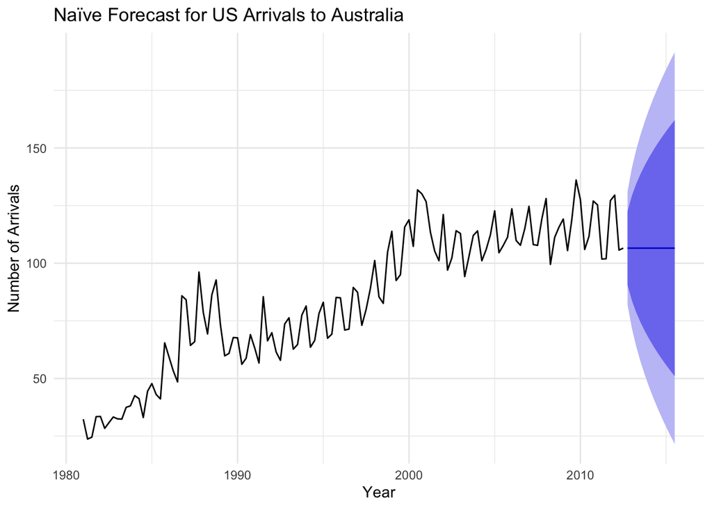

```r
autoplot(naive_forecast) +
  ggtitle("Naïve Forecast for US Arrivals to Australia") +
  xlab("Year") +
  ylab("Number of Arrivals") +
  theme_minimal()
```

## How Good is the Accuracy?

#### Overall from these results, we see that the Naive model is not the most accurate model to utilize. For example, the RMSE and MAE’s results show that there are large forecast errors, the MAPE indicates that the average forecast error is 11.83% of actual values which is very high, and the MASE is greater than 1, meaning that the Naive model performs worse than a basic benchmark.

## What Does It Predeict the Time Series Value Will Be in One Year?

#### The forecast for the next year will remain constant at the last observed value and the model assumes no trend, no growth, and no seasonal effects, leading to a flat forecast.